# Pertemuan 3 MPDW

# Persiapan Data

## Packages

```r
library(dLagM)
library(dynlm)
library(MLmetrics)
library(lmtest)
library(car)
```

## Impor & Pembagian Data

```r
data <- read.csv("C:\\Users\\NI KADEK ARISTA M\\Downloads\\Semester 5\\MPDW\\Pertemuan 3\\Praktikum\\NewDelhi_Air_quality.csv")

data <- data[, c("AQI", "o3")]

head(data)
```

```
##    AQI       o3
## 1 30.2 55.78995
## 2 28.2 54.93164
## 3 26.6 54.64554
## 4 25.0 55.07469
## 5 26.0 55.78995
## 6 26.0 56.50520
```

```r
# Membagi data menjadi training dan testing
n <- nrow(data)

train_size <- floor(0.8 * n)

train <- data[1:train_size, ]
test <- data[(train_size + 1):n, ]

# Mengubah format data menjadi objek Time Series (ts)
train.ts <- ts(train)
test.ts <- ts(test)
data.ts <- ts(data)
```

# Model Koyck

## Pemodelan

```r
model.koyck <- koyckDlm(
  x = train$o3,
  y = train$AQI
)

summary(model.koyck)
```

```
##
## Call:
## "Y ~ (Intercept) + Y.1 + X.t"
##
## Residuals:
##       Min        1Q    Median        3Q       Max
## -1.127670 -0.301407  0.001002  0.262601  1.103471
##
## Coefficients:
##             Estimate Std. Error t value Pr(>|t|)
## (Intercept)  0.54798    0.92878   0.590    0.558
## Y.1          0.41955    0.08223   5.102 4.63e-06 ***
## X.t          0.25830    0.04107   6.289 6.25e-08 ***
## ---
## Signif. codes:  0 '***' 0.001 '**' 0.01 '*' 0.05 '.' 0.1 ' ' 1
##
## Residual standard error: 0.5053 on 53 degrees of freedom
## Multiple R-Squared: 0.9463,  Adjusted R-squared: 0.9443
## Wald test: 423.7 on 2 and 53 DF,  p-value: < 2.2e-16
##
## Diagnostic tests:
## NULL
##
##                             alpha      beta       phi
## Geometric coefficients:  0.944071 0.2582957 0.4195528
```

## Peramalan

```r
# Meramalkan 15 periode ke depan
fore.koyck <- forecast(
  model = model.koyck,
  x = test$o3,
  h = nrow(test)
)

fore.koyck
```

```
## $forecasts
##  [1] 24.15387 23.05989 21.95429 21.12094 20.21706 19.74546 20.00947 20.67448
##  [9] 20.95348 21.07054 21.58152 23.08914 24.83015 26.29958 27.28558
##
## $call
## forecast.koyckDlm(model = model.koyck, x = test$o3, h = nrow(test))
##
## attr(,"class")
## [1] "forecast.koyckDlm" "dLagM"
```

```r
# Mengambil hasil ramalan Koyck
forecast.koyck <- fore.koyck$forecasts

# Data aktual
actual <- test$AQI

# Membandingkan hasil aktual dan ramalan
hasil.koyck <- data.frame(
  Aktual = actual,
  Forecast = forecast.koyck
)

hasil.koyck
```

```
##    Aktual Forecast
## 1      23 24.15387
## 2      22 23.05989
## 3      21 21.95429
## 4      20 21.12094
## 5      19 20.21706
## 6      19 19.74546
## 7      20 20.00947
## 8      21 20.67448
## 9      21 20.95348
## 10     21 21.07054
## 11     22 21.58152
## 12     24 23.08914
## 13     26 24.83015
## 14     27 26.29958
## 15     28 27.28558
```

```r
MAPE(
  y_pred = hasil.koyck$Forecast,
  y_true = hasil.koyck$Aktual
)
```

```
## [1] 0.03187326
```

Nilai MAPE model Koyck sebesar 0.03187326 atau sekitar 3.19%. Nilai tersebut menunjukkan bahwa rata-rata kesalahan absolut hasil peramalan model Koyck terhadap nilai aktual AQI relatif kecil.

# Regression with Distributed Lag (DLM)

```r
model.dlm <- dlm(
  x = train$o3,
  y = train$AQI,
  q = 2
)

model.dlm
```

```
## $model
##
## Call:
## lm(formula = model.formula, data = design)
##
## Coefficients:
## (Intercept)          x.t          x.1          x.2
##   -0.052782     0.476379    -0.005756    -0.008392
##
##
## $designMatrix
##     y.t      x.t      x.1      x.2
## 1  26.6 54.64554 54.93164 55.78995
## 2  25.0 55.07469 54.64554 54.93164
## 3  26.0 55.78995 55.07469 54.64554
```

[output cut: 64 more lines]

```r
finiteDLMauto(
  formula = AQI ~ o3,
  data = data.frame(train),
  q.min = 1,
  q.max = 10,
  model.type = "dlm",
  error.type = "AIC",
  trace = TRUE
)
```

```
##    q - k    MASE      AIC      BIC     GMRAE   MBRAE R.Adj.Sq  Ljung-Box
## 10    10 0.35051 22.97129 47.02321 14499.820 0.49589  0.98302 0.35474502
## 3      3 0.39875 27.06744 39.00134  6447.089 0.49480  0.98198 0.10728965
## 5      5 0.38245 27.17252 42.78247  7468.898 0.49506  0.98252 0.17930776
## 4      4 0.39892 27.90158 41.69362  8742.382 0.49838  0.98187 0.16589034
## 9      9 0.38342 29.59952 52.05393 11575.966 0.50164  0.98105 0.83879203
## 6      6 0.38046 29.81810 47.20453  6019.920 0.48473  0.98200 0.19113496
## 7      7 0.39444 30.91101 50.03124  7435.980 0.49025  0.98199 0.27024407
## 8      8 0.40121 31.26668 52.07671 10182.702 0.51165  0.98151 0.41738843
## 2      2 0.42869 46.47280 56.50947  6714.446 0.48891  0.97365 0.08751929
## 1      1 0.50971 90.38861 98.49001  6923.684 0.40817  0.94126 0.16081431
```

Berdasarkan hasil pemilihan lag menggunakan kriteria informasi, diperoleh lag optimum DLM sebesar q = 10. Artinya, model DLM terbaik menurut kriteria yang digunakan mempertimbangkan pengaruh O₃ pada periode berjalan hingga 10 periode sebelumnya terhadap AQI. Dengan demikian, model DLM dengan q = 10 digunakan sebagai model DLM optimum untuk tahap selanjutnya.

```r
# Model DLM Optimum
model.dlm.opt <- dlm(
  x = train$o3,
  y = train$AQI,
  q = 10
)

summary(model.dlm.opt)
```

```
##
## Call:
## lm(formula = model.formula, data = design)
##
## Residuals:
##     Min      1Q  Median      3Q     Max
## -0.5204 -0.1663  0.0356  0.1624  0.5130
##
## Coefficients:
##              Estimate Std. Error t value Pr(>|t|)
## (Intercept) -0.294780   0.931786  -0.316  0.75361
## x.t          0.405638   0.063702   6.368 2.54e-07 ***
## x.1          0.159000   0.133129   1.194  0.24038
## x.2         -0.052741   0.126788  -0.416  0.67997
## x.3         -0.148621   0.121282  -1.225  0.22860
## x.4          0.143544   0.124404   1.154  0.25638
## x.5         -0.007047   0.123348  -0.057  0.95476
## x.6         -0.127683   0.123191  -1.036  0.30709
## x.7          0.287823   0.121937   2.360  0.02396 *
## x.8         -0.399437   0.121443  -3.289  0.00230 **
## x.9          0.304147   0.103813   2.930  0.00594 **
## x.10        -0.098958   0.048025  -2.061  0.04684 *
## ---
## Signif. codes:  0 '***' 0.001 '**' 0.01 '*' 0.05 '.' 0.1 ' ' 1
##
## Residual standard error: 0.2715 on 35 degrees of freedom
## Multiple R-squared:  0.9871, Adjusted R-squared:  0.983
## F-statistic: 243.1 on 11 and 35 DF,  p-value: < 2.2e-16
##
## AIC and BIC values for the model:
##        AIC      BIC
## 1 22.97129 47.02321
```

```r
# Peramalan model DLM Optimum
fore.dlm.opt <- forecast(
  model = model.dlm.opt,
  x = test$o3,
  h = 15
)

fore.dlm.opt
```

```
## $forecasts
##  [1] 23.40514 21.79122 20.75754 20.09325 19.25114 18.84865 19.56151 20.98076
##  [9] 21.17891 20.56410 21.57565 23.70751 26.47347 27.65902 27.98734
##
## $call
## forecast.dlm(model = model.dlm.opt, x = test$o3, h = 15)
##
## attr(,"class")
## [1] "forecast.dlm" "dLagM"
```

```r
# MAPE Model DLM Optimum
mape.dlm.opt <- MAPE(
  fore.dlm.opt$forecasts,
  test$AQI
)

cat("MAPE Model DLM Optimum:", mape.dlm.opt, "\n")
```

```
## MAPE Model DLM Optimum: 0.01274404
```

Nilai MAPE model DLM optimum sebesar 0.01274404 atau sekitar 1.27%. Nilai tersebut menunjukkan bahwa rata-rata kesalahan absolut peramalan DLM terhadap nilai aktual AQI relatif kecil.

# Autoregressive Distributed Lag (ARDL)

## Pemodelan

```r
# Model ARDL dengan lag Y = 1 dan lag X = 1
model.ardl <- ardlDlm(
  formula = AQI ~ o3,
  data = train,
  p = 1,
  q = 1
)

summary(model.ardl)
```

```
##
## Time series regression with "ts" data:
## Start = 2, End = 57
##
## Call:
## dynlm(formula = as.formula(model.text), data = data)
##
## Residuals:
##     Min      1Q  Median      3Q     Max
## -1.0261 -0.2582  0.1254  0.2988  0.8683
##
## Coefficients:
##             Estimate Std. Error t value Pr(>|t|)
## (Intercept) -0.14906    0.67926  -0.219    0.827
## o3.t         0.47821    0.03429  13.946  < 2e-16 ***
## o3.1        -0.22331    0.04692  -4.759 1.59e-05 ***
## AQI.1        0.45264    0.06656   6.801 1.03e-08 ***
## ---
## Signif. codes:  0 '***' 0.001 '**' 0.01 '*' 0.05 '.' 0.1 ' ' 1
##
## Residual standard error: 0.3812 on 52 degrees of freedom
## Multiple R-squared:   0.97,  Adjusted R-squared:  0.9683
## F-statistic: 561.2 on 3 and 52 DF,  p-value: < 2.2e-16
```

Model ARDL awal dengan p = 1 dan q = 1 memiliki nilai R-squared sebesar 0.97 dan Adjusted R-squared sebesar 0.9683. Hal ini menunjukkan bahwa sekitar 97% variasi AQI dapat dijelaskan oleh O₃ dan lag AQI dalam model. F-statistic menghasilkan p-value < 2.2e-16, sehingga model secara keseluruhan signifikan pada taraf nyata 5%. Namun, model ini masih merupakan model awal sehingga dilakukan pemilihan lag untuk memperoleh struktur ARDL yang lebih optimal.

## Lag Optimum ARDL

```r
model.ardl.opt <- ardlBoundOrders(
  data = data.frame(train),
  ic = "AIC",
  formula = AQI ~ o3
)
min_p <- c()

for(i in 1:6){
  min_p[i] <- min(model.ardl.opt$Stat.table[[i]])
}

q_opt <- which(
  min_p == min(min_p, na.rm = TRUE)
)

p_opt <- which(
  model.ardl.opt$Stat.table[[q_opt]] ==
    min(model.ardl.opt$Stat.table[[q_opt]], na.rm = TRUE)
)

data.frame(
  "Lag_Y_opt(q)" = q_opt,
  "Lag_X_opt(p)" = p_opt,
  "AIC" = model.ardl.opt$min.Stat
)
```

```
##   Lag_Y_opt.q. Lag_X_opt.p.       AIC
## 1            5           13 -12.27606
```

Berdasarkan hasil pemilihan lag menggunakan kriteria AIC, diperoleh kombinasi lag optimum dengan lag Y = 5 dan lag X = 13, dengan nilai AIC sebesar -12.27606. Hal ini berarti model ARDL optimum mempertimbangkan lima lag AQI dan tiga belas lag O₃. Kombinasi lag tersebut selanjutnya digunakan untuk membangun model ARDL optimum.

```r
# Peramalan ARDL awal (p=1, q=1)
fore.ardl <- forecast(
  model = model.ardl,
  x = test$o3,
  h = 15
)

# MAPE ARDL awal
mape.ardl <- MAPE(
  fore.ardl$forecasts,
  test$AQI
)

cat("MAPE Model ARDL (1,1):", mape.ardl, "\n")
```

```
## MAPE Model ARDL (1,1): 0.006897306
```

```r
model.ardl.optimal <- ardlDlm(
  formula = AQI ~ o3,
  data = train,
  p = 13,
  q = 5
)

summary(model.ardl.optimal)
```

```
##
## Time series regression with "ts" data:
## Start = 14, End = 57
##
## Call:
## dynlm(formula = as.formula(model.text), data = data)
##
## Residuals:
##      Min       1Q   Median       3Q      Max
## -0.41464 -0.18468  0.04299  0.18081  0.43840
##
## Coefficients:
##             Estimate Std. Error t value Pr(>|t|)
## (Intercept) -0.75000    1.17770  -0.637  0.53026
## o3.t         0.40457    0.09102   4.445  0.00017 ***
## o3.1         0.22991    0.23680   0.971  0.34127
## o3.2        -0.10105    0.24938  -0.405  0.68892
## o3.3        -0.01254    0.25806  -0.049  0.96164
## o3.4         0.16947    0.21300   0.796  0.43404
## o3.5         0.03250    0.18826   0.173  0.86439
## o3.6        -0.16760    0.15214  -1.102  0.28155
## o3.7         0.25621    0.15587   1.644  0.11327
## o3.8        -0.27693    0.15888  -1.743  0.09412 .
## o3.9         0.13143    0.16914   0.777  0.44472
## o3.10        0.11860    0.18210   0.651  0.52103
## o3.11       -0.19144    0.19143  -1.000  0.32726
## o3.12        0.05851    0.16117   0.363  0.71974
## o3.13        0.01389    0.06819   0.204  0.84025
## AQI.1       -0.14475    0.21554  -0.672  0.50828
## AQI.2        0.04825    0.22155   0.218  0.82942
## AQI.3       -0.16347    0.24876  -0.657  0.51735
## AQI.4       -0.17118    0.21929  -0.781  0.44266
## AQI.5        0.01403    0.20934   0.067  0.94712
## ---
## Signif. codes:  0 '***' 0.001 '**' 0.01 '*' 0.05 '.' 0.1 ' ' 1
##
## Residual standard error: 0.2973 on 24 degrees of freedom
## Multiple R-squared:  0.9889, Adjusted R-squared:  0.9801
## F-statistic: 112.2 on 19 and 24 DF,  p-value: < 2.2e-16
```

asil estimasi ARDL optimum dengan p = 13 dan q = 5 menghasilkan nilai R-squared sebesar 0.9889 dan Adjusted R-squared sebesar 0.9801. Hal ini menunjukkan bahwa sekitar 98.89% variasi AQI pada data training dapat dijelaskan oleh O₃ dan nilai AQI pada periode-periode sebelumnya yang terdapat dalam model. F-statistic menghasilkan p-value < 2.2e-16 sehingga model secara keseluruhan signifikan pada taraf nyata 5%.

```r
fore.ardl.optimal <- forecast(
  model = model.ardl.optimal,
  x = test$o3,
  h = 15
)

mape.ardl.optimal <- MAPE(
  fore.ardl.optimal$forecasts,
  test$AQI
)

cat("MAPE Model ARDL Optimum:", mape.ardl.optimal, "\n")
```

```
## MAPE Model ARDL Optimum: 0.01190307
```

Nilai MAPE model ARDL optimum sebesar 0.01190307 atau sekitar 1.19%. Nilai tersebut menunjukkan bahwa rata-rata kesalahan absolut hasil peramalan ARDL terhadap nilai aktual AQI relatif kecil.

# Uji Asumsi

## Uji asumsi Koyck

```r
# Uji asumsi model Koyck
model.koyck.lm <- dynlm(
  AQI ~ o3 + L(AQI),
  data = train.ts
)

summary(model.koyck.lm)
```

```
##
## Time series regression with "ts" data:
## Start = 2, End = 57
##
## Call:
## dynlm(formula = AQI ~ o3 + L(AQI), data = train.ts)
##
## Residuals:
##      Min       1Q   Median       3Q      Max
## -0.78961 -0.30739 -0.06053  0.20120  1.70996
##
## Coefficients:
##             Estimate Std. Error t value Pr(>|t|)
## (Intercept) -0.27989    0.80546  -0.347 0.729596
## o3           0.35714    0.02728  13.091  < 2e-16 ***
## L(AQI)       0.23682    0.05781   4.096 0.000144 ***
## ---
## Signif. codes:  0 '***' 0.001 '**' 0.01 '*' 0.05 '.' 0.1 ' ' 1
##
## Residual standard error: 0.4524 on 53 degrees of freedom
## Multiple R-squared:  0.957,  Adjusted R-squared:  0.9554
## F-statistic: 589.6 on 2 and 53 DF,  p-value: < 2.2e-16
```

```r
# uji autokorelasi koyck
dwtest(model.koyck.lm)
```

```
##
##  Durbin-Watson test
##
## data:  model.koyck.lm
## DW = 1.687, p-value = 0.07733
## alternative hypothesis: true autocorrelation is greater than 0
```

```r
# uji heteroskedastisitas
bptest(model.koyck.lm)
```

```
##
##  studentized Breusch-Pagan test
##
## data:  model.koyck.lm
## BP = 22.69, df = 2, p-value = 1.183e-05
```

```r
# uji normalitas koyck
shapiro.test(residuals(model.koyck.lm))
```

```
##
##  Shapiro-Wilk normality test
##
## data:  residuals(model.koyck.lm)
## W = 0.93188, p-value = 0.003549
```

Berdasarkan uji Durbin-Watson diperoleh nilai DW sebesar 1.687 dengan p-value sebesar 0.07733. Karena p-value > 0.05, maka gagal menolak H₀. Dengan demikian, tidak terdapat cukup bukti untuk menyatakan adanya autokorelasi positif pada residual model Koyck pada taraf nyata 5%.

Hasil uji Breusch-Pagan menghasilkan p-value sebesar 1.183 × 10⁻⁵, yang lebih kecil dari 0.05. Oleh karena itu, H₀ ditolak. Hal ini menunjukkan bahwa residual model Koyck mengalami heteroskedastisitas.

Hasil uji Shapiro-Wilk menghasilkan p-value sebesar 0.003549, lebih kecil dari 0.05. Oleh karena itu, H₀ ditolak, sehingga residual model Koyck tidak berdistribusi normal pada taraf nyata 5%.

## Uji asumsi DLM

```r
# Uji asumsi DLM optimum
model.dlm.lm <- dynlm(
  AQI ~ o3 +
    L(o3, 1) +
    L(o3, 2) +
    L(o3, 3) +
    L(o3, 4) +
    L(o3, 5) +
    L(o3, 6) +
    L(o3, 7) +
    L(o3, 8) +
    L(o3, 9) +
    L(o3, 10),
  data = train.ts
)

summary(model.dlm.lm)
```

```
##
## Time series regression with "ts" data:
## Start = 11, End = 57
##
## Call:
## dynlm(formula = AQI ~ o3 + L(o3, 1) + L(o3, 2) + L(o3, 3) + L(o3,
##     4) + L(o3, 5) + L(o3, 6) + L(o3, 7) + L(o3, 8) + L(o3, 9) +
##     L(o3, 10), data = train.ts)
##
## Residuals:
##     Min      1Q  Median      3Q     Max
## -0.5204 -0.1663  0.0356  0.1624  0.5130
##
## Coefficients:
##              Estimate Std. Error t value Pr(>|t|)
## (Intercept) -0.294780   0.931786  -0.316  0.75361
## o3           0.405638   0.063702   6.368 2.54e-07 ***
## L(o3, 1)     0.159000   0.133129   1.194  0.24038
## L(o3, 2)    -0.052741   0.126788  -0.416  0.67997
## L(o3, 3)    -0.148621   0.121282  -1.225  0.22860
## L(o3, 4)     0.143544   0.124404   1.154  0.25638
## L(o3, 5)    -0.007047   0.123348  -0.057  0.95476
## L(o3, 6)    -0.127683   0.123191  -1.036  0.30709
## L(o3, 7)     0.287823   0.121937   2.360  0.02396 *
## L(o3, 8)    -0.399437   0.121443  -3.289  0.00230 **
## L(o3, 9)     0.304147   0.103813   2.930  0.00594 **
## L(o3, 10)   -0.098958   0.048025  -2.061  0.04684 *
## ---
## Signif. codes:  0 '***' 0.001 '**' 0.01 '*' 0.05 '.' 0.1 ' ' 1
##
## Residual standard error: 0.2715 on 35 degrees of freedom
## Multiple R-squared:  0.9871, Adjusted R-squared:  0.983
## F-statistic: 243.1 on 11 and 35 DF,  p-value: < 2.2e-16
```

```r
# Autokorelasi
dwtest(model.dlm.lm)
```

```
##
##  Durbin-Watson test
##
## data:  model.dlm.lm
## DW = 2.2518, p-value = 0.6603
## alternative hypothesis: true autocorrelation is greater than 0
```

```r
# Heteroskedastisitas
bptest(model.dlm.lm)
```

```
##
##  studentized Breusch-Pagan test
##
## data:  model.dlm.lm
## BP = 8.9642, df = 11, p-value = 0.6252
```

```r
# Normalitas
shapiro.test(residuals(model.dlm.lm))
```

```
##
##  Shapiro-Wilk normality test
##
## data:  residuals(model.dlm.lm)
## W = 0.97309, p-value = 0.3455
```

Uji Durbin-Watson menghasilkan nilai DW sebesar 2.2518 dengan p-value 0.6603. Karena p-value > 0.05, maka gagal menolak H₀. Dengan demikian, tidak terdapat cukup bukti adanya autokorelasi positif pada residual model DLM pada taraf nyata 5%.

Uji Breusch-Pagan menghasilkan p-value sebesar 0.6252, lebih besar dari 0.05. Oleh karena itu, gagal menolak H₀ sehingga tidak terdapat bukti adanya heteroskedastisitas pada residual model DLM.

Uji Shapiro-Wilk menghasilkan p-value sebesar 0.3455, lebih besar dari 0.05. Oleh karena itu, gagal menolak H₀ sehingga residual model DLM tidak menunjukkan penyimpangan yang signifikan dari distribusi normal pada taraf nyata 5%.

## Uji asumsi ARDL

```r
model.ardl.lm <- dynlm(
  AQI ~ o3 +
    L(o3, 1) +
    L(o3, 2) +
    L(o3, 3) +
    L(o3, 4) +
    L(o3, 5) +
    L(AQI, 1) +
    L(AQI, 2) +
    L(AQI, 3) +
    L(AQI, 4) +
    L(AQI, 5) +
    L(AQI, 6) +
    L(AQI, 7) +
    L(AQI, 8) +
    L(AQI, 9) +
    L(AQI, 10) +
    L(AQI, 11) +
    L(AQI, 12) +
    L(AQI, 13),
  data = train.ts
)

summary(model.ardl.lm)
```

```
##
## Time series regression with "ts" data:
## Start = 14, End = 57
##
## Call:
## dynlm(formula = AQI ~ o3 + L(o3, 1) + L(o3, 2) + L(o3, 3) + L(o3,
##     4) + L(o3, 5) + L(AQI, 1) + L(AQI, 2) + L(AQI, 3) + L(AQI,
##     4) + L(AQI, 5) + L(AQI, 6) + L(AQI, 7) + L(AQI, 8) + L(AQI,
##     9) + L(AQI, 10) + L(AQI, 11) + L(AQI, 12) + L(AQI, 13), data = train.ts)
##
## Residuals:
##      Min       1Q   Median       3Q      Max
## -0.50061 -0.19664 -0.02575  0.24265  0.42023
##
## Coefficients:
##              Estimate Std. Error t value Pr(>|t|)
## (Intercept) -0.914189   1.290579  -0.708 0.485548
## o3           0.408668   0.107727   3.794 0.000886 ***
## L(o3, 1)     0.282875   0.272737   1.037 0.309993
## L(o3, 2)    -0.079089   0.272947  -0.290 0.774489
## L(o3, 3)     0.004053   0.279300   0.015 0.988543
## L(o3, 4)     0.230336   0.273371   0.843 0.407783
## L(o3, 5)     0.005256   0.221722   0.024 0.981283
## L(AQI, 1)   -0.269604   0.211785  -1.273 0.215209
## L(AQI, 2)   -0.062321   0.214167  -0.291 0.773556
## L(AQI, 3)   -0.092972   0.245555  -0.379 0.708300
## L(AQI, 4)   -0.324334   0.243757  -1.331 0.195839
## L(AQI, 5)   -0.031011   0.239121  -0.130 0.897894
## L(AQI, 6)   -0.056181   0.169159  -0.332 0.742683
## L(AQI, 7)    0.024935   0.137197   0.182 0.857306
## L(AQI, 8)   -0.045789   0.139927  -0.327 0.746327
## L(AQI, 9)    0.046246   0.131569   0.351 0.728285
## L(AQI, 10)   0.065826   0.111901   0.588 0.561856
## L(AQI, 11)  -0.102498   0.109654  -0.935 0.359234
## L(AQI, 12)  -0.033886   0.115195  -0.294 0.771165
## L(AQI, 13)   0.065576   0.070725   0.927 0.363055
## ---
## Signif. codes:  0 '***' 0.001 '**' 0.01 '*' 0.05 '.' 0.1 ' ' 1
##
## Residual standard error: 0.3281 on 24 degrees of freedom
## Multiple R-squared:  0.9865, Adjusted R-squared:  0.9757
## F-statistic: 91.97 on 19 and 24 DF,  p-value: < 2.2e-16
```

```r
# Uji autokorelasi
dwtest(model.ardl.lm)
```

```
##
##  Durbin-Watson test
##
## data:  model.ardl.lm
## DW = 2.0483, p-value = 0.3461
## alternative hypothesis: true autocorrelation is greater than 0
```

```r
# Uji heteroskedastisitas
bptest(model.ardl.lm)
```

```
##
##  studentized Breusch-Pagan test
##
## data:  model.ardl.lm
## BP = 23.137, df = 19, p-value = 0.2313
```

```r
# Uji normalitas
shapiro.test(residuals(model.ardl.lm))
```

```
##
##  Shapiro-Wilk normality test
##
## data:  residuals(model.ardl.lm)
## W = 0.96322, p-value = 0.1716
```

Uji Breusch-Pagan menghasilkan p-value sebesar 0.2313, lebih besar dari 0.05. Oleh karena itu, gagal menolak H₀ sehingga tidak terdapat bukti adanya heteroskedastisitas pada residual model ARDL.

Uji Shapiro-Wilk menghasilkan p-value sebesar 0.1716, lebih besar dari 0.05. Oleh karena itu, gagal menolak H₀ sehingga residual model ARDL tidak menunjukkan penyimpangan yang signifikan dari distribusi normal pada taraf nyata 5%.

# Mencari Deviance

```r
# Deviance Model Koyck
deviance.koyck <- sum(
  (hasil.koyck$Aktual - hasil.koyck$Forecast)^2
)

cat("Deviance Model Koyck:", deviance.koyck, "\n")
```

```
## Deviance Model Koyck: 10.14643
```

```r
# Deviance Model DLM Optimum
deviance.dlm.opt <- sum(
  (test$AQI - fore.dlm.opt$forecasts)^2
)

cat("Deviance Model DLM Optimum:", deviance.dlm.opt, "\n")
```

```
## Deviance Model DLM Optimum: 1.700108
```

```r
# Deviance Model ARDL Optimum
deviance.ardl.optimal <- sum(
  (test$AQI - fore.ardl.optimal$forecasts)^2
)

cat("Deviance Model ARDL Optimum:", deviance.ardl.optimal, "\n")
```

```
## Deviance Model ARDL Optimum: 1.47325
```

# Visualisasi

## Grafik Koyck

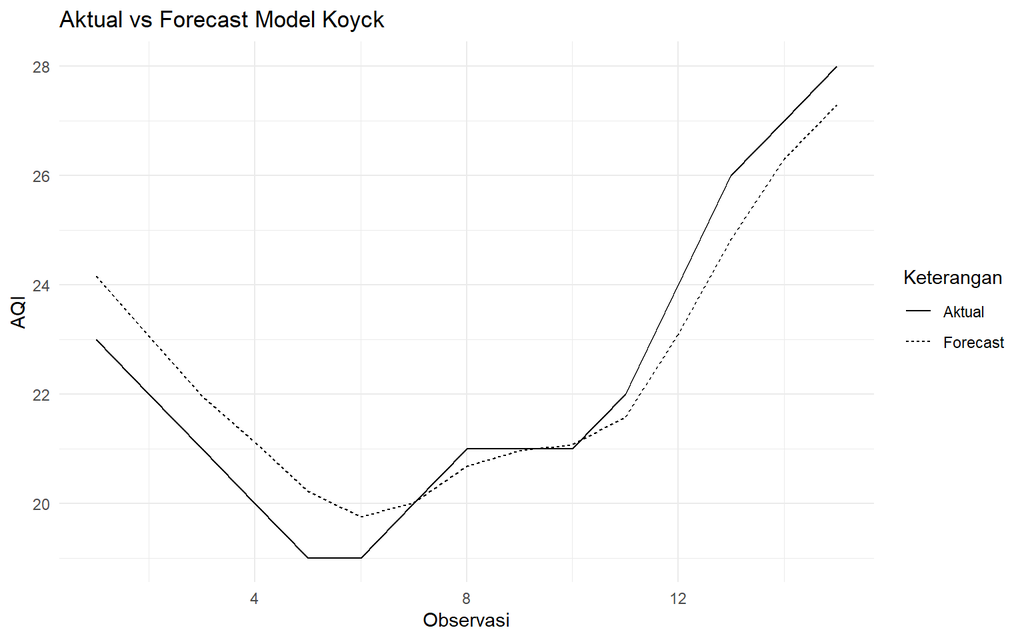

```r
library(ggplot2)

ggplot(hasil.koyck, aes(x = 1:nrow(hasil.koyck))) +
  geom_line(aes(y = Aktual, linetype = "Aktual")) +
  geom_line(aes(y = Forecast, linetype = "Forecast")) +
  labs(
    title = "Aktual vs Forecast Model Koyck",
    x = "Observasi",
    y = "AQI",
    linetype = "Keterangan"
  ) +
  theme_minimal()
```

Grafik menunjukkan perbandingan antara nilai AQI aktual dan hasil peramalan model Koyck pada data testing. Secara umum, hasil forecast mengikuti pola pergerakan nilai aktual, tetapi pada beberapa periode masih terdapat selisih antara nilai aktual dan forecast. Hal ini sejalan dengan nilai MAPE dan deviance Koyck yang relatif lebih besar dibandingkan kedua model lainnya.

## Grafik DLM

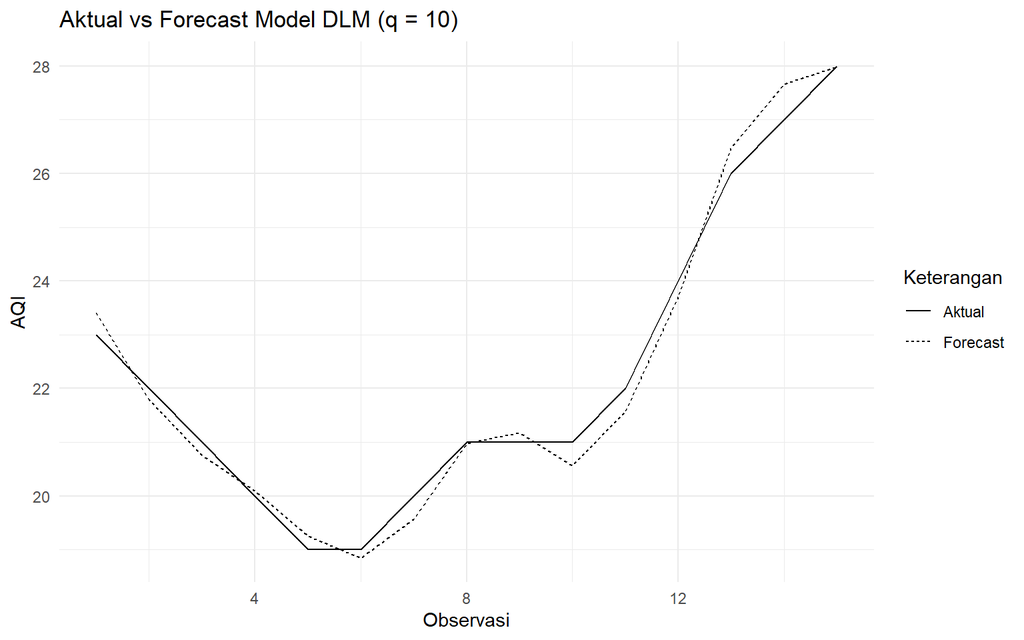

```r
# Membuat data aktual dan forecast DLM optimum
hasil.dlm.opt <- data.frame(
  Aktual = test$AQI,
  Forecast = as.numeric(fore.dlm.opt$forecasts)
)

# Grafik Aktual vs Forecast DLM
ggplot(hasil.dlm.opt, aes(x = 1:nrow(hasil.dlm.opt))) +
  geom_line(aes(y = Aktual, linetype = "Aktual")) +
  geom_line(aes(y = Forecast, linetype = "Forecast")) +
  labs(
    title = "Aktual vs Forecast Model DLM (q = 10)",
    x = "Observasi",
    y = "AQI",
    linetype = "Keterangan"
  ) +
  theme_minimal()
```

Grafik menunjukkan bahwa hasil peramalan model DLM dengan q = 10 secara umum mengikuti pola nilai AQI aktual dengan lebih baik dibandingkan model Koyck. Selisih antara nilai aktual dan forecast terlihat relatif kecil pada sebagian besar periode pengamatan. Hal tersebut didukung oleh nilai MAPE sebesar 0.01274404 dan deviance sebesar 1.700108.

## Grafik ARDL

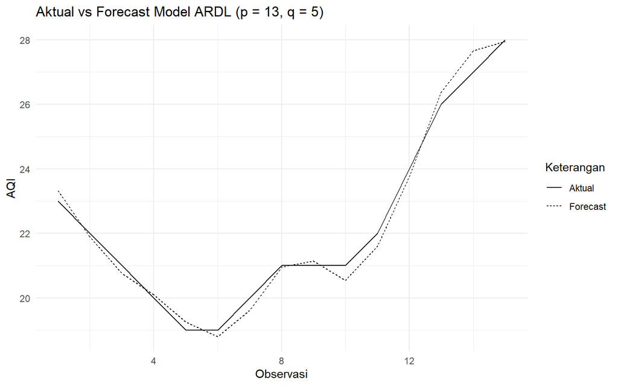

```r
# Membuat data aktual dan forecast ARDL optimum
hasil.ardl.optimal <- data.frame(
  Aktual = test$AQI,
  Forecast = as.numeric(fore.ardl.optimal$forecasts)
)

# Grafik Aktual vs Forecast ARDL
ggplot(hasil.ardl.optimal, aes(x = 1:nrow(hasil.ardl.optimal))) +
  geom_line(aes(y = Aktual, linetype = "Aktual")) +
  geom_line(aes(y = Forecast, linetype = "Forecast")) +
  labs(
    title = "Aktual vs Forecast Model ARDL (p = 13, q = 5)",
    x = "Observasi",
    y = "AQI",
    linetype = "Keterangan"
  ) +
  theme_minimal()
```

Grafik menunjukkan bahwa hasil peramalan model ARDL optimum dengan p = 13 dan q = 5 mengikuti pola nilai AQI aktual dengan cukup baik. Hasil forecast terlihat dekat dengan nilai aktual pada sebagian besar periode pengujian. Hal ini konsisten dengan nilai MAPE sebesar 0.01190307 dan deviance sebesar 1.47325 yang merupakan nilai terendah dibandingkan model Koyck dan DLM.

# Interpretasi

# Kesimpulan

Berdasarkan analisis model Koyck, Distributed Lag Model (DLM), dan Autoregressive Distributed Lag (ARDL) untuk memodelkan AQI berdasarkan O₃, diperoleh lag optimum DLM sebesar q = 10 dan ARDL sebesar p = 13 dan q = 5. Hasil evaluasi menunjukkan bahwa Koyck memiliki MAPE 0.03187326 dan deviance 10.14643, DLM memiliki MAPE 0.01274404 dan deviance 1.700108, sedangkan ARDL memiliki MAPE 0.01190307 dan deviance 1.47325.